# School belonging data analysis

Author

Michael Kammer

Published

2025-04-22

# 1 Background

This frequentist analysis for the school belonging analysis task follows the statistical analysis plan by Michael Kammer dated 16.4.2025 (and referring to the task description for the school belonging task with the same date).

# 2 Setup and data

Data were provided by Mariana Nold by mail on 3.1.2025 (`pisa2018.RData`). This dataset is already pre-processed with one small exception.

- ATT4 is computed as the quartile of the mean level of truancy (ATT01) in the individuals school as per the SAP.

```r
T_START = Sys.time()
SUFFIX = ""

# data handling and printing
library(tidyverse)
library(glue)
library(magrittr)
library(patchwork)
library(gtsummary)
library(gt)

# modelling
library(lme4)
library(MuMIn)
library(DHARMa)

# plotting
library(GGally)

# parallel
library(doFuture)

# required bot not loaded
# ranger
# pracma

rm(list = c("pisa2018"))
load("Data/Raw/pisa2018.Rdata")

pisa2018 %<>%
    group_by(school.id) %>%
    mutate(ATTMEAN = mean(ATT01)) %>%
    ungroup() %>%
    mutate(
        ATT4 = cut(ATTMEAN,
                   breaks = quantile(ATTMEAN, probs = c(0, 0.25, 0.5, 0.75, 1)),
                   labels = 1:4,
                   include.lowest = TRUE)
    )
```

## 2.1 Helper functions

Code for helper functions.

```r
plot_density_and_box <- function(plotdf, v) {
    list(
        ggplot(plotdf, aes(x = .data[[v]])) +
            geom_density() +
            theme_bw() +
            theme(axis.title.x = element_blank(),
                  axis.text.x = element_blank(),
                  axis.ticks.x = element_blank(),
                  plot.margin = margin()),
        ggplot(plotdf, aes(x = .data[[v]], y = 0)) +
            geom_boxplot(outlier.shape = NA) +
            geom_jitter(height = 0.25, width = 0, alpha = 0.1) +
            theme_bw() +
            theme(axis.text.y = element_blank(),
                  axis.title.y = element_blank(),
                  axis.ticks.y = element_blank(),
                  panel.grid.minor.y = element_blank(),
                  panel.grid.major.y = element_blank(),
                  plot.margin = margin(0))
    ) %>%
        wrap_plots(nrow = 2, heights = c(0.8, 0.2))
}

#' @title Data.frame with residuals for lme4 model
#'
#' @details
#' See e.g. https://support.sas.com/documentation/cdl/en/statug/63033/HTML/default/viewer.htm#statug_mixed_sect024.htm
#' Results are equal to SAS output via outp (conditional) and outpm (marginal)
#' options.
#'
#' Note that the computation of the hatvalues can be really slow with large
#' datasets.
#'
#' @return
#' Data.frame with columns
#'
#' - pred_conditional: conditional prediction, i.e. using random effects
#' - pred_marginal: marginal prediction, i.e. only using fixed effects
#' - resid_conditional: conditional residuals, i.e. outcome - pred_conditional
#' - resid_marginal: marginal residuals, i.e. outcome - pred_marginal
#' - resid_conditional_stud: studentized conditional residuals, i.e. scaled
#'     by estimated variances
residuals_merMod <- function(m) {
    dresid = data.frame(pred_conditional = predict(m),
                      pred_marginal = predict(m, re.form = ~ 0))
    dresid$resid_conditional = m@resp$y - dresid$pred_conditional
    dresid$resid_marginal = m@resp$y - dresid$pred_marginal
    dresid$resid_conditional_stud = dresid$resid_conditional /
        summary(m)$sigma * sqrt(1 - hatvalues(m))
    return(dresid)
}

#' @title SAS style diagnostics for lme4 model
#'
#' @return
#' Plot object from ggplot2
diagnostics_residuals <- function(m, pt_alpha = 0.3) {
    dout = residuals_merMod(m)

    pm = ggplot(dout, aes(x = pred_marginal, y = resid_marginal)) +
        geom_point(shape = 1, alpha = pt_alpha) +
        geom_abline(intercept = 0, slope = 0) +
        theme_bw()

    pmd = ggplot(dout, aes(x = resid_marginal)) +
        geom_histogram(aes(y = ..density..),
                       binwidth = bw.nrd0(dout$resid_marginal) * 2,
                       fill = "#aaaaaa", color = "black") +
        geom_density(aes(y = ..density..),
                     size = 1.5) +
        theme_bw()

    pmq = ggplot(dout, aes(sample = resid_marginal)) +
        stat_qq() +
        stat_qq_line() +
        ylab("resid_marginal") +
        theme_bw()

    pc = ggplot(dout, aes(x = pred_conditional, y = resid_conditional_stud)) +
        geom_point(shape = 1, alpha = pt_alpha) +
        geom_abline(intercept = 0, slope = 0) +
        theme_bw()

    pcd = ggplot(dout, aes(x = resid_conditional_stud)) +
        geom_histogram(aes(y = ..density..),
                       binwidth = bw.nrd0(dout$resid_conditional_stud) * 2,
                       fill = "#aaaaaa", color = "black") +
        geom_density(aes(y = ..density..),
                     size = 1.5) +
        theme_bw()

    pcq = ggplot(dout, aes(sample = resid_conditional_stud)) +
        stat_qq() +
        stat_qq_line() +
        ylab("resid_conditional_stud") +
        theme_bw()

    p = wrap_plots(pm, pmd, pmq, pc, pcd, pcq)

    return(list(dresid = dout, p = p))
}

diagnostics_calibration <- function(m) {
    plotdf = data.frame(
        fitted_marginal = predict(m, re.form = NA),
        fitted_conditional = predict(m, re.form = NULL),
        observed = model.frame(m)[, 1]
    )

    wrap_plots(
        ggplot(plotdf, aes(x = observed, y = fitted_marginal)) +
            geom_point(shape = 21) +
            theme_bw(),
        ggplot(plotdf, aes(x = observed, y = fitted_conditional)) +
            geom_point(shape = 21) +
            theme_bw()
    )
}

metrics_merMod <- function(m, observed, trafo = identity,
                           duan = FALSE) {
    fitted_marginal = predict(m, re.form = NA)
    fitted_conditional = predict(m, re.form = NULL)

    if (duan) {
        dr = residuals_merMod(m)
        for (i in 1:nrow(dr)) {
            fitted_marginal[i] = mean(trafo(fitted_marginal[i] + dr$resid_marginal))
            fitted_conditional[i] = mean(trafo(fitted_conditional[i] + dr$resid_conditional))
        }
    } else {
        fitted_marginal = trafo(fitted_marginal)
        fitted_conditional = trafo(fitted_conditional)
    }

    c(
        rmse_marginal = sqrt(mean((fitted_marginal - observed)^2)),
        rmse_conditional = sqrt(mean((fitted_conditional - observed)^2)),
        mean_bias_marginal = mean(fitted_marginal - observed),
        mean_bias_conditional = mean(fitted_conditional - observed)
    )
}
```

# 3 Variables

As outlined in Table 1 in the task description.

```r
VARIABLES = list(
    outcome = "belong",
    focal = c("bull", "ATT4"),
    nonfocal = c("female", "nld", "scie_std", "aca", "val", "comp", "ndiff",
                 "nfof", "native", "nfewbooks", "joyread", "goal", "mot",
                 "res", "swbp", "mean", "parent_sup", "ndis_clim", "GYM", "UNI")
)

glue("{length(VARIABLES$nonfocal)} non-focal variables used for modeling according to SAP:
     {VARIABLES$nonfocal |> paste0(collapse = ', ')}")
```

```
20 non-focal variables used for modeling according to SAP:
female, nld, scie_std, aca, val, comp, ndiff, nfof, native, nfewbooks, joyread, goal, mot, res, swbp, mean, parent_sup, ndis_clim, GYM, UNI
```

## 3.1 Overview

Elementary overview of distributions and correlations.

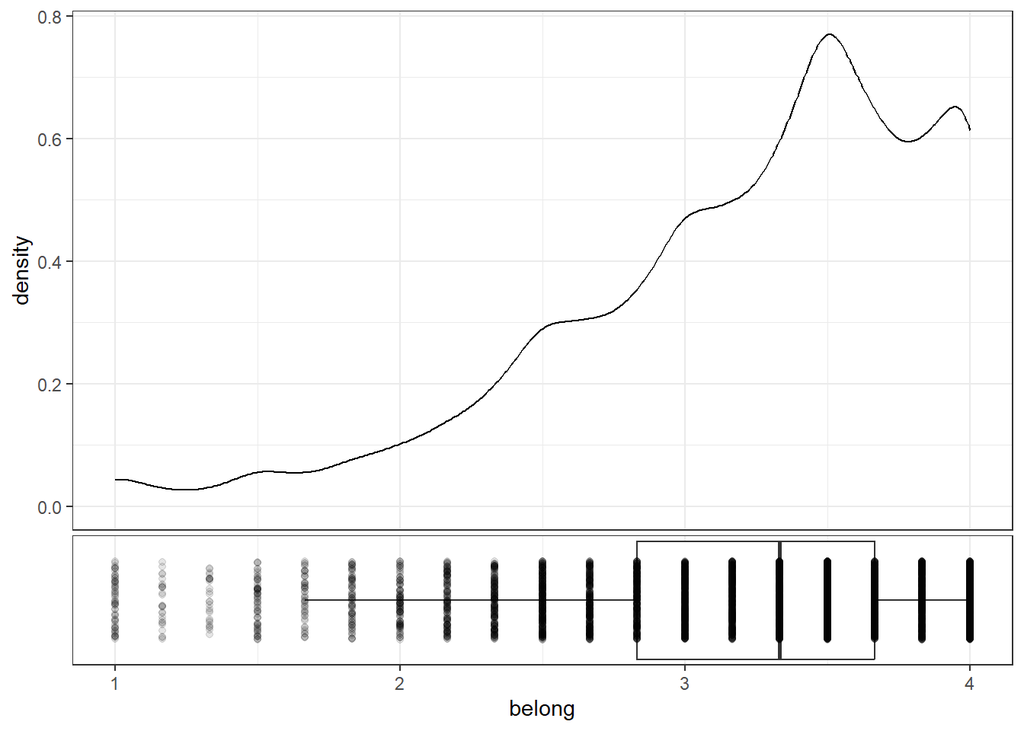

```r
plot_density_and_box(pisa2018, "belong")
```

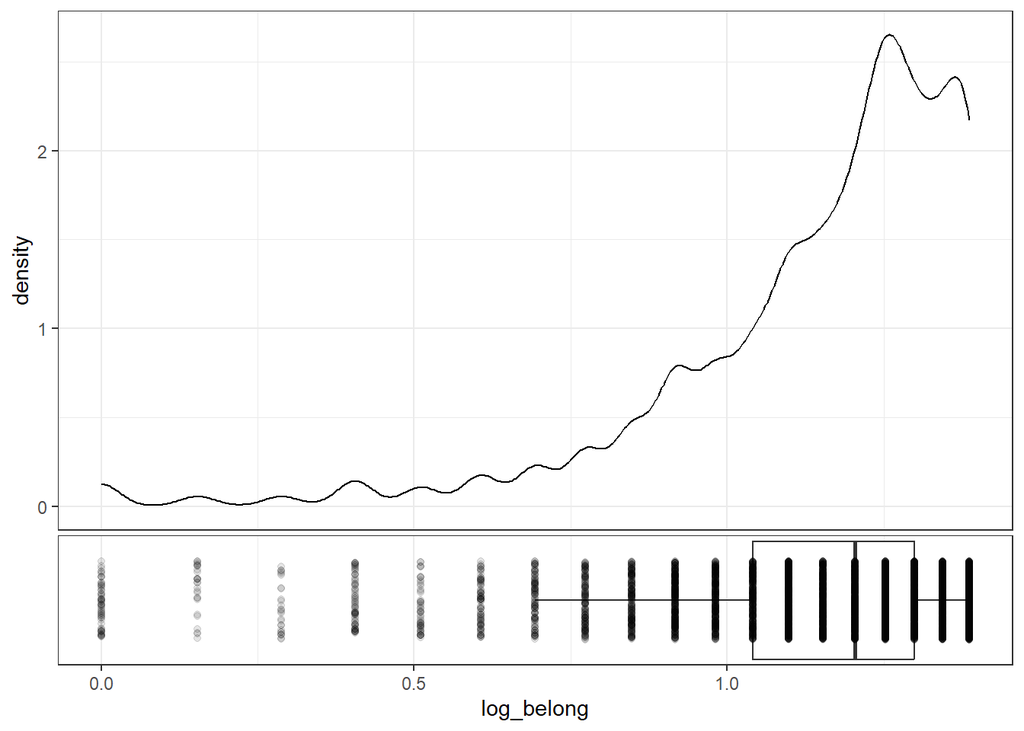

```r
plot_density_and_box(pisa2018 %>% mutate(log_belong = log(belong)), "log_belong")
```

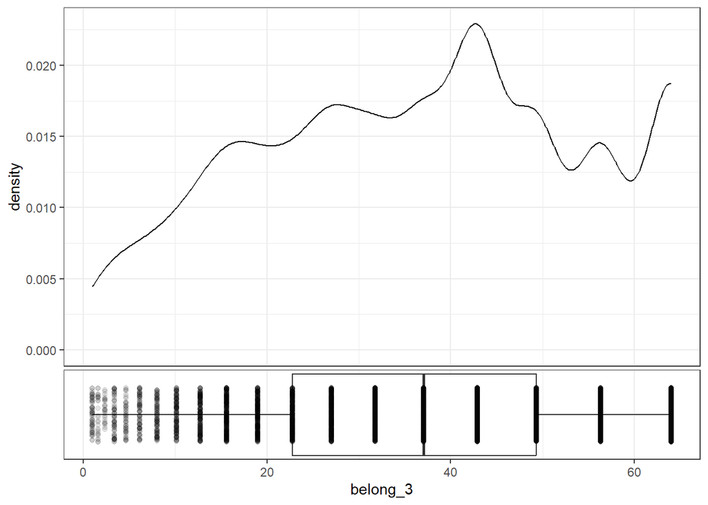

```r
plot_density_and_box(pisa2018 %>% mutate(belong_3 = belong^3), "belong_3")
```

```r
pisa2018 %>%
    select(one_of(unlist(VARIABLES))) %>%
    tbl_summary(
        type = all_continuous() ~ "continuous2",
        statistic = list(all_continuous() ~ c("{median} ({p25}, {p75})",
                                              "{mean} ({sd})",
                                             "{min}, {max}"))
    )
```

| **Characteristic** | **N = 6,489**<sup>1</sup> |
| --- | --- |
| belong |  |
| Median (Q1, Q3) | 3.33 (2.83, 3.67) |
| Mean (SD) | 3.21 (0.65) |
| Min, Max | 1.00, 4.00 |
| bull | 694 (11%) |
| ATT4 |  |
| 1 | 1,703 (26%) |
| 2 | 1,639 (25%) |
| 3 | 1,616 (25%) |
| 4 | 1,531 (24%) |
| female | 3,182 (49%) |
| nld | 5,126 (79%) |
| scie_std |  |
| Median (Q1, Q3) | 0.08 (-0.68, 0.77) |
| Mean (SD) | 0.04 (0.99) |
| Min, Max | -3.39, 3.05 |
| aca | 2,041 (31%) |
| val |  |
| Median (Q1, Q3) | 0.07 (-0.40, 1.02) |
| Mean (SD) | 0.00 (1.00) |
| Min, Max | -3.24, 1.02 |
| comp |  |
| Median (Q1, Q3) | -0.10 (-0.59, 0.89) |
| Mean (SD) | 0.02 (0.99) |
| Min, Max | -3.07, 1.39 |
| ndiff |  |
| Median (Q1, Q3) | 0.29 (-0.72, 0.79) |
| Mean (SD) | 0.02 (1.00) |
| Min, Max | -3.24, 1.29 |
| nfof |  |
| Median (Q1, Q3) | 0.04 (-0.76, 0.84) |
| Mean (SD) | 0.00 (1.00) |
| Min, Max | -1.95, 1.63 |
| native | 5,287 (81%) |
| nfewbooks | 4,822 (74%) |
| joyread |  |
| Median (Q1, Q3) | -0.14 (-0.83, 0.77) |
| Mean (SD) | 0.01 (1.01) |
| Min, Max | -1.51, 1.92 |
| goal |  |
| Median (Q1, Q3) | -0.08 (-0.44, 0.64) |
| Mean (SD) | 0.00 (1.00) |
| Min, Max | -2.60, 1.72 |
| mot |  |
| Median (Q1, Q3) | 0.04 (-0.48, 0.56) |
| Mean (SD) | 0.00 (1.00) |
| Min, Max | -3.06, 1.59 |
| res |  |
| Median (Q1, Q3) | -0.03 (-0.40, 0.71) |
| Mean (SD) | 0.00 (1.00) |
| Min, Max | -3.71, 1.81 |
| swbp |  |
| Median (Q1, Q3) | 0.19 (-0.59, 1.24) |
| Mean (SD) | 0.11 (1.00) |
| Min, Max | -3.07, 1.24 |
| mean |  |
| Median (Q1, Q3) | 0.17 (-0.65, 0.58) |
| Mean (SD) | 0.00 (1.00) |
| Min, Max | -2.29, 1.40 |
| parent_sup |  |
| Median (Q1, Q3) | 0.43 (-0.49, 0.88) |
| Mean (SD) | 0.01 (1.00) |
| Min, Max | -3.23, 0.88 |
| ndis_clim |  |
| Median (Q1, Q3) | -0.12 (-0.89, 0.64) |
| Mean (SD) | 0.00 (1.00) |
| Min, Max | -1.15, 2.69 |
| GYM | 4,142 (64%) |
| UNI |  |
| Median (Q1, Q3) | 0.34 (0.14, 0.53) |
| Mean (SD) | 0.35 (0.24) |
| Min, Max | 0.00, 0.96 |

<sup>1</sup> n (%)

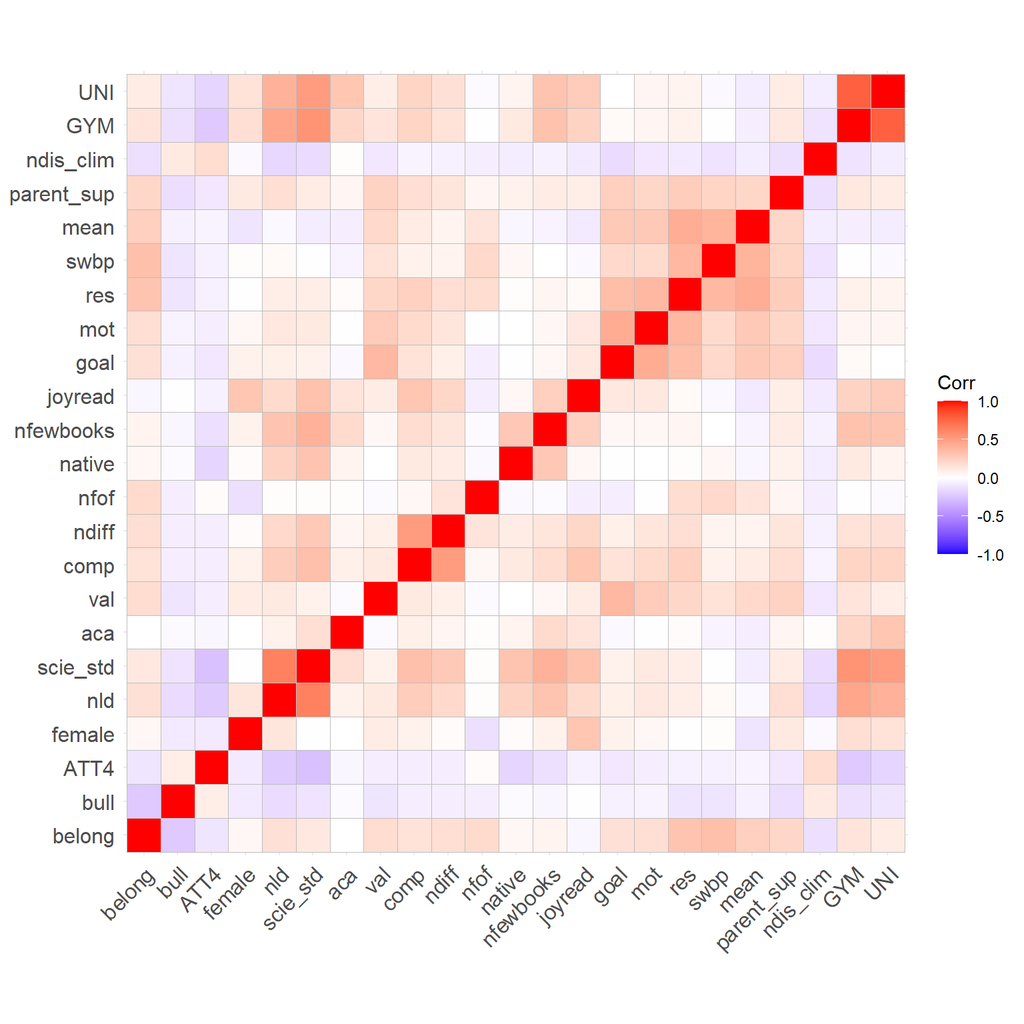

```r
cormat = pisa2018 %>%
    select(one_of(unlist(VARIABLES))) %>%
    mutate(across(where(is.factor), as.numeric)) %>%
    cor(use = "pairwise.complete.obs", method = "spearman")

ggcorrplot::ggcorrplot(cormat)
```

Focal predictors - important for target estimands.

```r
tbl_cross(pisa2018, bull, ATT4)
```

|  | ATT4 1 | ATT4 2 | ATT4 3 | ATT4 4 | Total |  |
| --- | --- | --- | --- | --- | --- | --- |
| bull |  |  |  |  |  |  |
| 0 | 1,572 | 1,492 | 1,425 | 1,306 | 5,795 |  |
| 1 | 131 | 147 | 191 | 225 | 694 |  |
| Total | 1,703 | 1,639 | 1,616 | 1,531 | 6,489 |  |

# 4 Analysis

## 4.1 Model without transformation

```r
f_m = sprintf("belong ~ bull * ATT4 + %s + (1 | school.id)",
              paste0(VARIABLES$nonfocal, collapse = " + ")) %>%
    as.formula()

m = lmer(f_m, data = pisa2018, REML = FALSE)
```

```
boundary (singular) fit: see help('isSingular')
```

```r
summary(m)
```

```
Linear mixed model fit by maximum likelihood  ['lmerMod']
Formula: belong ~ bull * ATT4 + female + nld + scie_std + aca + val +
    comp + ndiff + nfof + native + nfewbooks + joyread + goal +
    mot + res + swbp + mean + parent_sup + ndis_clim + GYM +
    UNI + (1 | school.id)
   Data: pisa2018

     AIC      BIC   logLik deviance df.resid
 11577.0  11780.3  -5758.5  11517.0     6459

Scaled residuals:
    Min      1Q  Median      3Q     Max
-4.6228 -0.4567  0.1763  0.6577  3.5117

Random effects:
 Groups    Name        Variance Std.Dev.
 school.id (Intercept) 0.0000   0.0000
 Residual              0.3454   0.5877
Number of obs: 6489, groups:  school.id, 221

Fixed effects:
             Estimate Std. Error t value
(Intercept)  3.142886   0.034130  92.085
bull        -0.437543   0.053809  -8.131
ATT42       -0.012019   0.021607  -0.556
ATT43       -0.062757   0.022032  -2.848
ATT44       -0.065048   0.023119  -2.814
female       0.035648   0.016445   2.168
nld          0.067076   0.024939   2.690
scie_std     0.005185   0.012022   0.431
aca         -0.006994   0.016876  -0.414
val          0.040227   0.008027   5.012
comp         0.018518   0.008928   2.074
ndiff        0.043561   0.008516   5.115
nfof         0.050255   0.007785   6.455
native      -0.010564   0.020816  -0.508
nfewbooks    0.011675   0.019183   0.609
joyread     -0.062492   0.008640  -7.233
goal         0.002559   0.008812   0.290
mot          0.010219   0.008486   1.204
res          0.065097   0.009051   7.192
swbp         0.107812   0.008529  12.641
mean         0.029763   0.008810   3.379
parent_sup   0.027798   0.007998   3.475
ndis_clim   -0.021110   0.007686  -2.747
GYM          0.057554   0.024195   2.379
UNI          0.036878   0.047543   0.776
bull:ATT42   0.111176   0.073937   1.504
bull:ATT43   0.129569   0.070220   1.845
bull:ATT44   0.179439   0.068480   2.620
```

```
Correlation matrix not shown by default, as p = 28 > 12.
Use print(x, correlation=TRUE)  or
    vcov(x)        if you need it
```

```
optimizer (nloptwrap) convergence code: 0 (OK)
boundary (singular) fit: see help('isSingular')
```

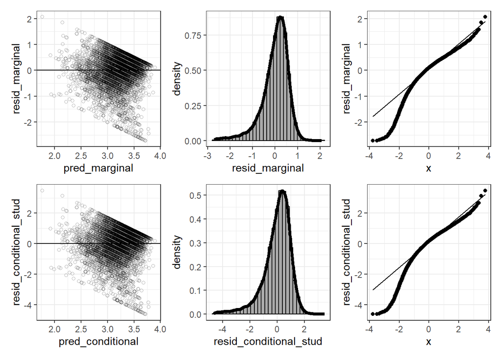

```r
diagnostics_residuals(m)$p
```

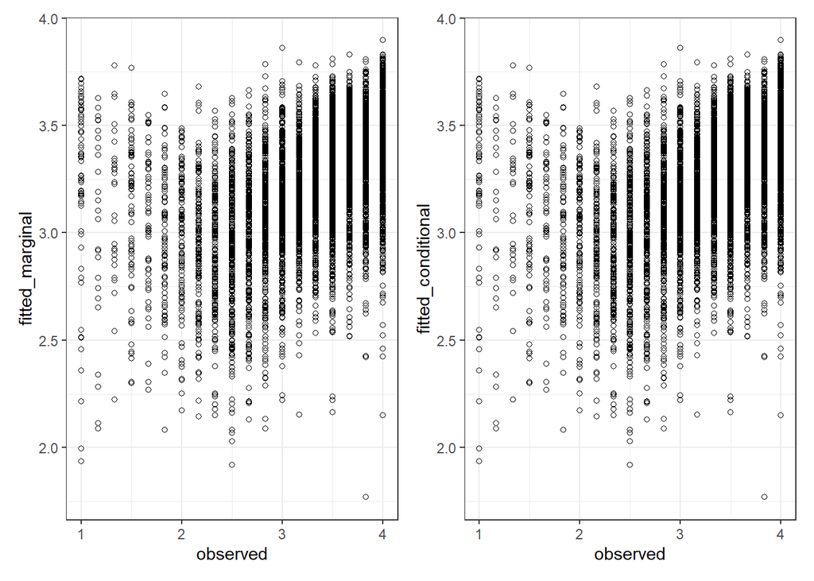

```r
diagnostics_calibration(m)
```

```r
r.squaredGLMM(m)
```

```
           R2m       R2c
[1,] 0.1945911 0.1945911
```

```r
metrics_merMod(m, pisa2018$belong)
```

```
        rmse_marginal      rmse_conditional    mean_bias_marginal
         5.877151e-01          5.877151e-01         -2.176926e-15
mean_bias_conditional
        -2.176926e-15
```

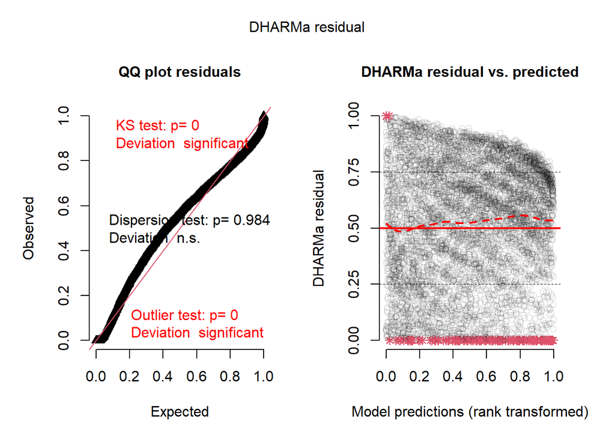

```r
# quantile residuals
s = simulateResiduals(m, seed = 26, plot = TRUE)
```

## 4.2 Model with log transformation

This model does not really improve the prediction capabilities or the residuals.

```r
f_mt = sprintf("log(belong) ~ bull * ATT4 + %s + (1 | school.id)",
              paste0(VARIABLES$nonfocal, collapse = " + ")) %>%
    as.formula()

mt = lmer(f_mt, data = pisa2018, REML = FALSE)
```

```
boundary (singular) fit: see help('isSingular')
```

```r
summary(mt)
```

```
Linear mixed model fit by maximum likelihood  ['lmerMod']
Formula: log(belong) ~ bull * ATT4 + female + nld + scie_std + aca + val +
    comp + ndiff + nfof + native + nfewbooks + joyread + goal +
    mot + res + swbp + mean + parent_sup + ndis_clim + GYM +
    UNI + (1 | school.id)
   Data: pisa2018

     AIC      BIC   logLik deviance df.resid
  -644.1   -440.7    352.0   -704.1     6459

Scaled residuals:
    Min      1Q  Median      3Q     Max
-5.7051 -0.2869  0.2267  0.5817  3.0181

Random effects:
 Groups    Name        Variance Std.Dev.
 school.id (Intercept) 0.00000  0.0000
 Residual              0.05253  0.2292
Number of obs: 6489, groups:  school.id, 221

Fixed effects:
              Estimate Std. Error t value
(Intercept)  1.124e+00  1.331e-02  84.479
bull        -1.671e-01  2.098e-02  -7.963
ATT42       -3.820e-03  8.426e-03  -0.453
ATT43       -2.288e-02  8.592e-03  -2.663
ATT44       -2.397e-02  9.016e-03  -2.658
female       1.174e-02  6.413e-03   1.830
nld          1.982e-02  9.726e-03   2.038
scie_std     4.445e-03  4.688e-03   0.948
aca         -3.345e-03  6.581e-03  -0.508
val          1.517e-02  3.130e-03   4.847
comp         4.486e-03  3.482e-03   1.288
ndiff        1.363e-02  3.321e-03   4.103
nfof         1.489e-02  3.036e-03   4.906
native      -3.783e-03  8.118e-03  -0.466
nfewbooks    4.218e-03  7.481e-03   0.564
joyread     -1.991e-02  3.369e-03  -5.908
goal        -1.789e-05  3.437e-03  -0.005
mot          2.094e-03  3.309e-03   0.633
res          2.106e-02  3.530e-03   5.967
swbp         3.560e-02  3.326e-03  10.703
mean         8.405e-03  3.436e-03   2.447
parent_sup   9.234e-03  3.119e-03   2.960
ndis_clim   -8.559e-03  2.997e-03  -2.856
GYM          1.452e-02  9.436e-03   1.538
UNI          1.447e-02  1.854e-02   0.781
bull:ATT42   3.786e-02  2.883e-02   1.313
bull:ATT43   4.896e-02  2.738e-02   1.788
bull:ATT44   7.215e-02  2.671e-02   2.702
```

```
Correlation matrix not shown by default, as p = 28 > 12.
Use print(x, correlation=TRUE)  or
    vcov(x)        if you need it
```

```
optimizer (nloptwrap) convergence code: 0 (OK)
boundary (singular) fit: see help('isSingular')
```

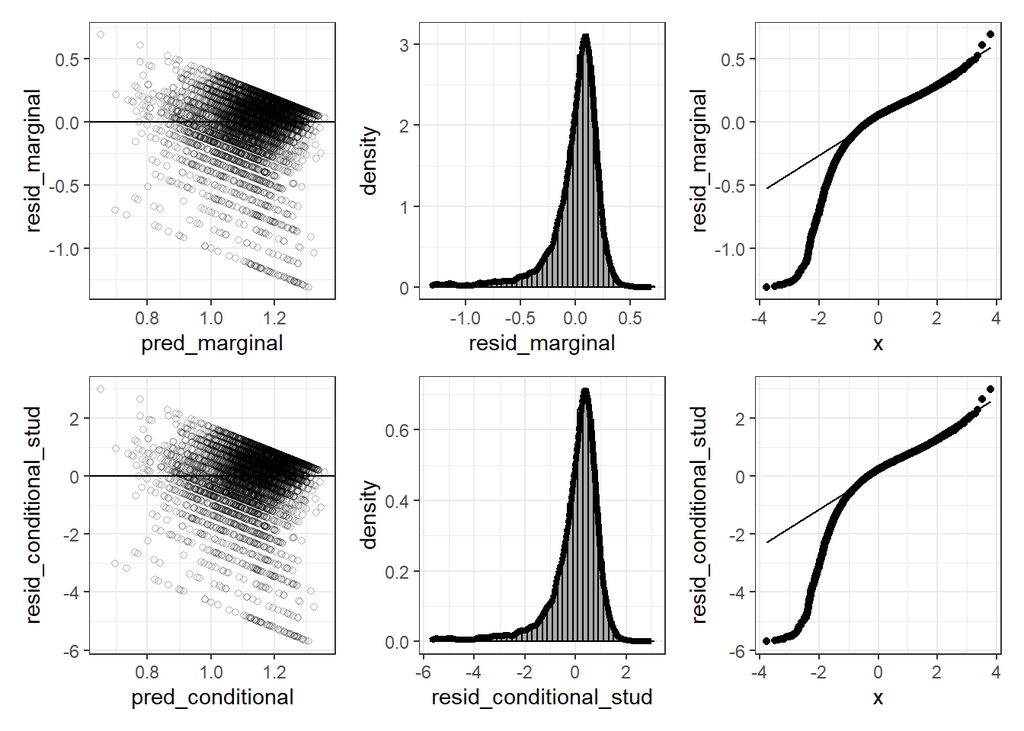

```r
diagnostics_residuals(mt)$p
```

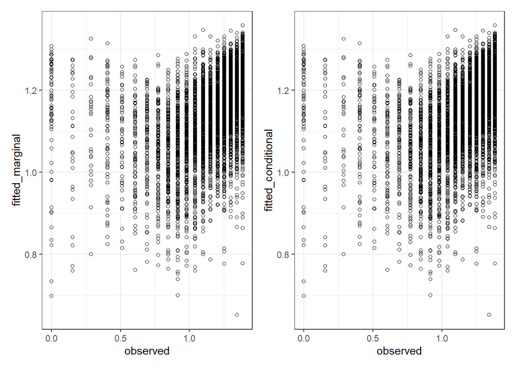

```r
diagnostics_calibration(mt)
```

```r
r.squaredGLMM(mt)
```

```
           R2m       R2c
[1,] 0.1511561 0.1511561
```

```r
metrics_merMod(mt, pisa2018$belong, exp)
```

```
        rmse_marginal      rmse_conditional    mean_bias_marginal
           0.59224232            0.59224232           -0.07033271
mean_bias_conditional
          -0.07033271
```

```r
metrics_merMod(mt, pisa2018$belong, exp, duan = TRUE)
```

```
        rmse_marginal      rmse_conditional    mean_bias_marginal
         0.5881357489          0.5881357489          0.0009675063
mean_bias_conditional
         0.0009675063
```

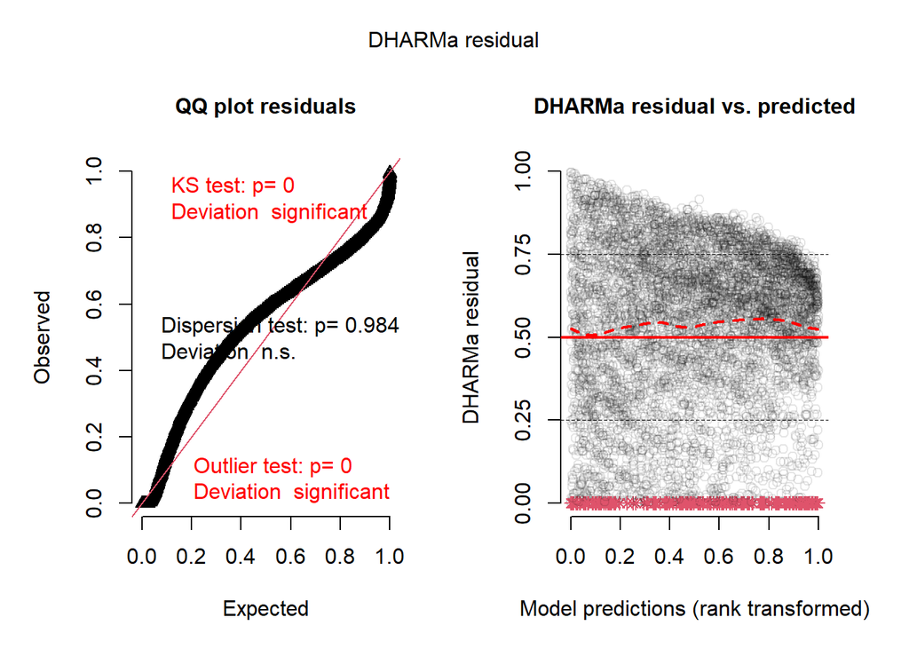

```r
# quantile residuals
s = simulateResiduals(mt, seed = 26, plot = TRUE)
```

## 4.3 Model with cube transformation

As the outcome has negative skew, power transformations may work well, although it does not improve predictive capabilities.

```r
pisa2018 %<>% mutate(belong_3 = belong^3)
f_mt1 = sprintf("belong_3 ~ bull * ATT4 + %s + (1 | school.id)",
              paste0(VARIABLES$nonfocal, collapse = " + ")) %>%
    as.formula()

mt1 = lmer(f_mt1, data = pisa2018, REML = FALSE)
```

```
boundary (singular) fit: see help('isSingular')
```

```r
summary(mt1)
```

```
Linear mixed model fit by maximum likelihood  ['lmerMod']
Formula: belong_3 ~ bull * ATT4 + female + nld + scie_std + aca + val +
    comp + ndiff + nfof + native + nfewbooks + joyread + goal +
    mot + res + swbp + mean + parent_sup + ndis_clim + GYM +
    UNI + (1 | school.id)
   Data: pisa2018

     AIC      BIC   logLik deviance df.resid
 54065.8  54269.2 -27002.9  54005.8     6459

Scaled residuals:
    Min      1Q  Median      3Q     Max
-3.3292 -0.6437  0.0311  0.7275  3.9468

Random effects:
 Groups    Name        Variance Std.Dev.
 school.id (Intercept)   0       0.00
 Residual              241      15.52
Number of obs: 6489, groups:  school.id, 221

Fixed effects:
             Estimate Std. Error t value
(Intercept)  34.14070    0.90153  37.870
bull        -10.62822    1.42134  -7.478
ATT42        -0.47751    0.57073  -0.837
ATT43        -1.75757    0.58196  -3.020
ATT44        -1.72836    0.61069  -2.830
female        0.96826    0.43438   2.229
nld           2.22959    0.65876   3.385
scie_std     -0.18569    0.31756  -0.585
aca          -0.07289    0.44577  -0.164
val           1.08600    0.21202   5.122
comp          0.76671    0.23583   3.251
ndiff         1.39258    0.22495   6.191
nfof          1.65537    0.20564   8.050
native       -0.14112    0.54984  -0.257
nfewbooks     0.35604    0.50671   0.703
joyread      -1.95250    0.22822  -8.555
goal          0.15583    0.23278   0.669
mot           0.41685    0.22416   1.860
res           1.99959    0.23907   8.364
swbp          3.27544    0.22528  14.539
mean          1.00024    0.23270   4.298
parent_sup    0.76695    0.21127   3.630
ndis_clim    -0.45046    0.20302  -2.219
GYM           2.12094    0.63911   3.319
UNI           0.93820    1.25581   0.747
bull:ATT42    3.20342    1.95299   1.640
bull:ATT43    3.25237    1.85483   1.753
bull:ATT44    4.29747    1.80887   2.376
```

```
Correlation matrix not shown by default, as p = 28 > 12.
Use print(x, correlation=TRUE)  or
    vcov(x)        if you need it
```

```
optimizer (nloptwrap) convergence code: 0 (OK)
boundary (singular) fit: see help('isSingular')
```

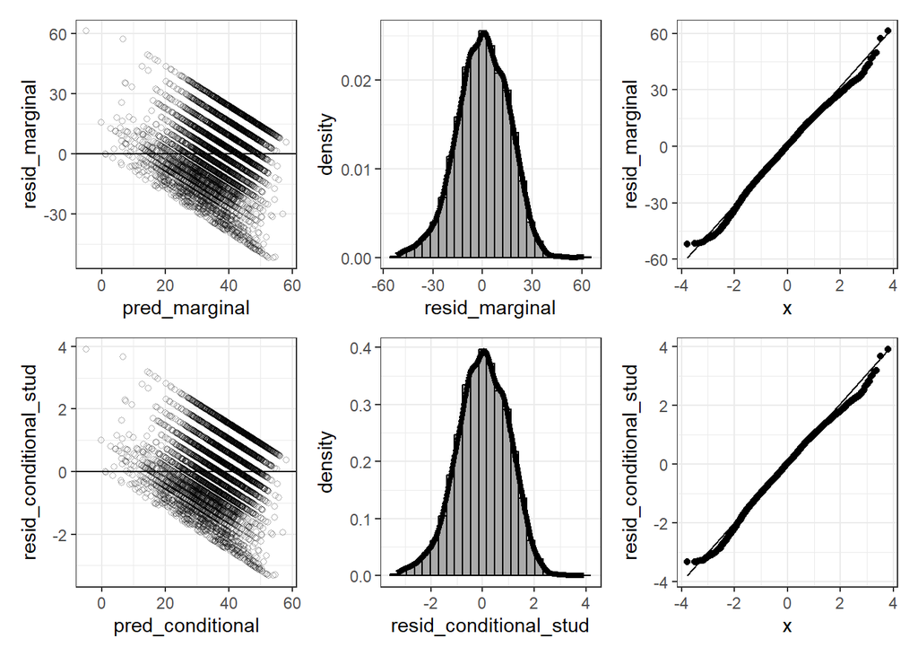

```r
diagnostics_residuals(mt1)$p
```

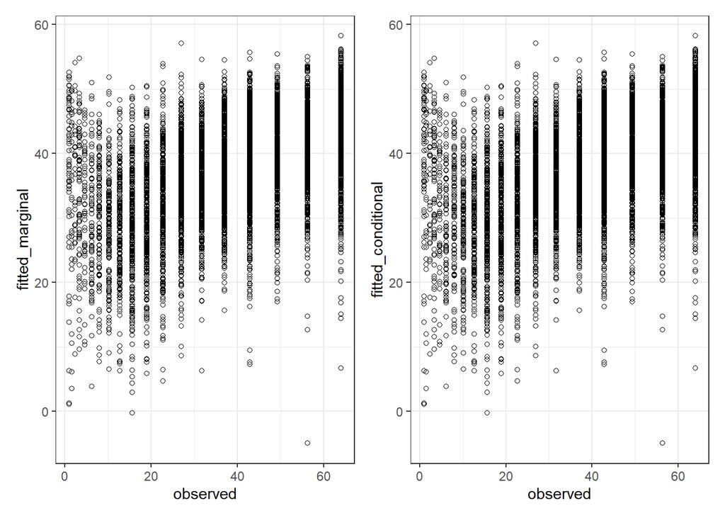

```r
diagnostics_calibration(mt1)
```

```r
r.squaredGLMM(mt1)
```

```
           R2m       R2c
[1,] 0.2319791 0.2319791
```

```r
metrics_merMod(mt1, pisa2018$belong, function(x) {pracma::nthroot(x, 3)})
```

```
        rmse_marginal      rmse_conditional    mean_bias_marginal
           0.60256770            0.60256770            0.09514493
mean_bias_conditional
           0.09514493
```

```r
metrics_merMod(mt1, pisa2018$belong, function(x) {pracma::nthroot(x, 3)},
               duan = TRUE)
```

```
        rmse_marginal      rmse_conditional    mean_bias_marginal
           0.61274933            0.61274933           -0.06463142
mean_bias_conditional
          -0.06463142
```

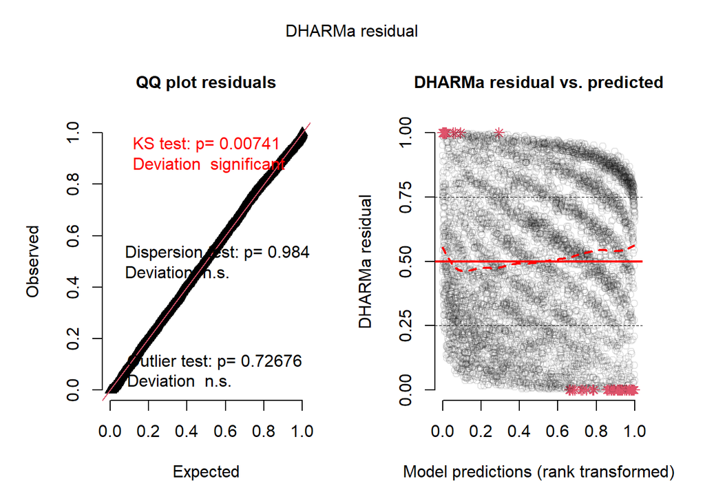

```r
# quantile residuals
s = simulateResiduals(mt1, seed = 26, plot = TRUE)
```

## 4.4 Target estimands

Follow SAP to create representative students. We compute this for all models, but finally only use the one with lowest prediction RMSE (not clarified in SAP but adopted here). This is not a clear choice however, since the different models are better in different aspects and the rmse is only apparent performance (i.e. model fit). Here it would lead to choose the simplest model without transformation.

```r
preddf = pisa2018 %>%
    select(bull, ATT4, one_of(VARIABLES$nonfocal)) %>%
    # 1) create subsets of data by focal predictors
    group_by(bull, ATT4) %>%
    # 2) compute 1st, 2nd, 3rd quartiles in subsets
    reframe(
        across(everything(), ~ quantile(.x, probs = c(0.25, 0.5, 0.75))),
        quantile = 1:3
    )

# 3) apply models
# note that random intercepts are degenerate, so no need to marginalize results
preddf$pred_m = predict(m, newdata = preddf, re.form = NA)
preddf$pred_mt = predict(mt, newdata = preddf, re.form = NA)
preddf$pred_mt1 = predict(mt1, newdata = preddf, re.form = NA)
```

## 4.5 Model comparison

Compare predictions (demonstrates high correlation between models and only minimal differences besides scaling).

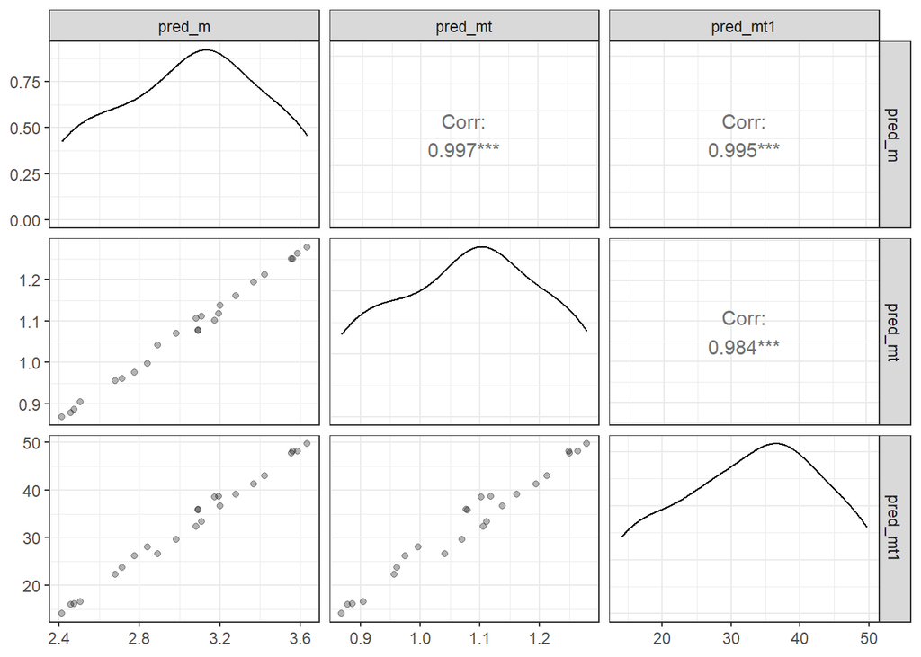

```r
ggpairs(preddf %>% select(starts_with("pred")),
                lower = list(continuous = wrap(ggally_points, alpha = 0.3))) +
    theme_bw()
```

## 4.6 Simulate from random intercepts

This step will be skipped, since the random intercept distribution is degenerate in all models.

## 4.7 Bootstrap

Simulate 1000 bootstraps for chosen model.

### 4.7.1 Bootstrap indices

```r
set.seed(13376)
b = 1000
bootstraps = map(1:b, ~ sample(1:nrow(pisa2018), nrow(pisa2018), replace = TRUE))

glue("Statistics of relative frequency of unique samples per bootstrap:")
```

```
Statistics of relative frequency of unique samples per bootstrap:
```

```r
(map_dbl(bootstraps, n_distinct) / nrow(pisa2018)) %>% summary()
```

```
   Min. 1st Qu.  Median    Mean 3rd Qu.    Max.
 0.6200  0.6295  0.6321  0.6321  0.6348  0.6446
```

### 4.7.2 Run bootstrap

```r
f_b = sprintf("belong ~ bull * ATT4 + %s + (1 | school.id)",
              paste0(VARIABLES$nonfocal, collapse = " + ")) %>%
    as.formula()

do_bootstrap <- function(df, ind, f_b, VARIABLES) {
    df_bi = df[ind, ]
    m_bi = lmer(f_b, data = df_bi, REML = FALSE)

    preddf_bi = df_bi %>%
        select(bull, ATT4, one_of(VARIABLES$nonfocal)) %>%
        group_by(bull, ATT4) %>%
        reframe(
            across(everything(), ~ quantile(.x, probs = c(0.25, 0.5, 0.75))),
            quantile = 1:3
        )
    preddf_bi$pred_bi = predict(m_bi, newdata = preddf, re.form = NA)
    # take random effect variation and residual variance into account
    preddf_bi$sim_bi = simulate(m_bi, nsim = 1, newdata = preddf %>%
                                    mutate(school.id = 0), re.form = NA,
                                allow.new.levels = TRUE)[[1]]

    list(
        preddf_bi = preddf_bi %>% select(bull, ATT4, pred_bi, sim_bi, quantile)
    )
}
```

```r
file_bootstrap = file.path(params$folder_analysis,
                           sprintf("bootstrap%s.rds", SUFFIX))
if (!file.exists(file_bootstrap)) {
    glue("Running bootstraps and saving to {file_bootstrap}") %>% print()

    plan(multisession, workers = 10)
    res_b = foreach(
        i = seq_along(bootstraps),
        .errorhandling = "pass",
        .options.future = list(seed = 15)
    ) %dofuture%  {
        t_start = Sys.time()
        res = do_bootstrap(pisa2018, bootstraps[[i]], f_b, VARIABLES)
        res$runtime = difftime(now(), t_start, units = "s") %>% as.numeric()
        res
    }
    plan(sequential)
    saveRDS(res_b, file_bootstrap)
} else {
    glue("Reading bootstrap results from {file_bootstrap}") %>% print()
    res_b = readRDS(file_bootstrap)
}
```

```
Reading bootstrap results from Data/Processed/bootstrap.rds
```

```r
glue("Runtime per bootstrap in hours:")
```

```
Runtime per bootstrap in hours:
```

```r
summary(map_dbl(res_b, 'runtime')) / 3600
```

```
     Min.   1st Qu.    Median      Mean   3rd Qu.      Max.
4.096e-05 6.384e-05 7.173e-05 7.609e-05 8.107e-05 1.601e-04
```

# 5 Final result

Display target estimands and variability as table. We sort by bullying, to ease comparison across levels of ATT and quantiles.

Prediction intervals based on prediction without residual variance or random effect variation.

```r
res_b_summary = bind_rows(map(res_b, "preddf_bi")) %>%
    group_by(bull, ATT4, quantile) %>%
    reframe(
        pred = quantile(pred_bi, probs = c(0.025, 0.25, 0.75, 0.975)),
        pred_quantile = c("q2.5", "q25", "q75", "q97.5")
    ) %>%
    pivot_wider(id_cols = c(bull, ATT4, quantile),
                names_from = pred_quantile, values_from = pred)

res = preddf %>%
    select(bull, ATT4, quantile, pred = pred_m) %>%
    left_join(res_b_summary, by = c("bull", "ATT4", "quantile"))

res$result = sprintf("%s<br>50%% [%s, %s]<br>95%% [%s, %s]",
                   round(res$pred, 2),
                   round(res$q25, 2), round(res$q75, 2),
                   round(res$q2.5, 2), round(res$q97.5, 2))

res %>%
    select(bull, ATT4, quantile, result) %>%
    pivot_wider(id_cols = c(ATT4, quantile),
                names_from = bull, values_from = result) %>%
    arrange(ATT4, quantile) %>%
    gt() %>%
    tab_style(
        style = list(cell_fill("#EEEEEE")),
        locations = cells_body(rows = ATT4 %in% c(2, 4))
    ) %>%
    fmt_markdown(columns = everything()) %>%
    cols_align("center", c("0", "1")) %>%
    tab_spanner(label = "bull", columns = c("0", "1")) %>%
    tab_options(quarto.disable_processing = TRUE)
```

| ATT4 | quantile | bull 0 | bull 1 |
| --- | --- | --- | --- |
| 1 | 1 | 3.08 50% [3.06, 3.1] 95% [3.03, 3.13] | 2.46 50% [2.41, 2.5] 95% [2.33, 2.59] |
| 1 | 2 | 3.42 50% [3.41, 3.44] 95% [3.38, 3.46] | 2.77 50% [2.73, 2.82] 95% [2.65, 2.9] |
| 1 | 3 | 3.63 50% [3.62, 3.65] 95% [3.59, 3.68] | 3.09 50% [3.04, 3.14] 95% [2.96, 3.23] |
| 2 | 1 | 3.11 50% [3.09, 3.13] 95% [3.05, 3.16] | 2.48 50% [2.44, 2.52] 95% [2.36, 2.6] |
| 2 | 2 | 3.37 50% [3.35, 3.38] 95% [3.33, 3.4] | 2.84 50% [2.81, 2.89] 95% [2.73, 2.97] |
| 2 | 3 | 3.59 50% [3.57, 3.6] 95% [3.54, 3.63] | 3.17 50% [3.14, 3.22] 95% [3.05, 3.3] |
| 3 | 1 | 2.98 50% [2.96, 3] 95% [2.93, 3.04] | 2.41 50% [2.38, 2.45] 95% [2.32, 2.51] |
| 3 | 2 | 3.28 50% [3.27, 3.3] 95% [3.24, 3.33] | 2.71 50% [2.68, 2.75] 95% [2.62, 2.81] |
| 3 | 3 | 3.56 50% [3.54, 3.57] 95% [3.5, 3.61] | 3.09 50% [3.06, 3.13] 95% [2.99, 3.19] |
| 4 | 1 | 2.89 50% [2.87, 2.91] 95% [2.83, 2.95] | 2.51 50% [2.47, 2.54] 95% [2.42, 2.6] |
| 4 | 2 | 3.2 50% [3.19, 3.22] 95% [3.15, 3.25] | 2.68 50% [2.65, 2.71] 95% [2.59, 2.77] |
| 4 | 3 | 3.56 50% [3.54, 3.58] 95% [3.51, 3.62] | 3.19 50% [3.17, 3.24] 95% [3.1, 3.3] |

Prediction intervals accounting for random effect variation and residual variance.

```r
res_b_summary = bind_rows(map(res_b, "preddf_bi")) %>%
    group_by(bull, ATT4, quantile) %>%
    reframe(
        pred = quantile(sim_bi, probs = c(0.025, 0.25, 0.75, 0.975)),
        pred_quantile = c("q2.5", "q25", "q75", "q97.5")
    ) %>%
    pivot_wider(id_cols = c(bull, ATT4, quantile),
                names_from = pred_quantile, values_from = pred)

res = preddf %>%
    select(bull, ATT4, quantile, pred = pred_m) %>%
    left_join(res_b_summary, by = c("bull", "ATT4", "quantile"))

res$result = sprintf("%s<br>50%% [%s, %s]<br>95%% [%s, %s]",
                   round(res$pred, 2),
                   round(res$q25, 2), round(res$q75, 2),
                   round(res$q2.5, 2), round(res$q97.5, 2))

res %>%
    select(bull, ATT4, quantile, result) %>%
    pivot_wider(id_cols = c(ATT4, quantile),
                names_from = bull, values_from = result) %>%
    arrange(ATT4, quantile) %>%
    gt() %>%
    tab_style(
        style = list(cell_fill("#EEEEEE")),
        locations = cells_body(rows = ATT4 %in% c(2, 4))
    ) %>%
    fmt_markdown(columns = everything()) %>%
    cols_align("center", c("0", "1")) %>%
    tab_spanner(label = "bull", columns = c("0", "1")) %>%
    tab_options(quarto.disable_processing = TRUE)
```

| ATT4 | quantile | bull 0 | bull 1 |
| --- | --- | --- | --- |
| 1 | 1 | 3.08 50% [2.66, 3.46] 95% [1.91, 4.2] | 2.46 50% [2.06, 2.84] 95% [1.28, 3.64] |
| 1 | 2 | 3.42 50% [2.98, 3.8] 95% [2.23, 4.6] | 2.77 50% [2.38, 3.19] 95% [1.69, 3.91] |
| 1 | 3 | 3.63 50% [3.21, 4.01] 95% [2.45, 4.74] | 3.09 50% [2.65, 3.48] 95% [1.84, 4.31] |
| 2 | 1 | 3.11 50% [2.71, 3.55] 95% [1.96, 4.3] | 2.48 50% [2.09, 2.91] 95% [1.32, 3.61] |
| 2 | 2 | 3.37 50% [2.95, 3.75] 95% [2.25, 4.56] | 2.84 50% [2.47, 3.3] 95% [1.68, 4.04] |
| 2 | 3 | 3.59 50% [3.21, 3.98] 95% [2.42, 4.73] | 3.17 50% [2.72, 3.55] 95% [2.02, 4.31] |
| 3 | 1 | 2.98 50% [2.63, 3.39] 95% [1.8, 4.12] | 2.41 50% [2.04, 2.8] 95% [1.26, 3.56] |
| 3 | 2 | 3.28 50% [2.87, 3.66] 95% [2.14, 4.35] | 2.71 50% [2.3, 3.13] 95% [1.62, 3.84] |
| 3 | 3 | 3.56 50% [3.18, 3.96] 95% [2.46, 4.74] | 3.09 50% [2.69, 3.51] 95% [2.02, 4.26] |
| 4 | 1 | 2.89 50% [2.53, 3.24] 95% [1.83, 3.98] | 2.51 50% [2.08, 2.86] 95% [1.28, 3.69] |
| 4 | 2 | 3.2 50% [2.79, 3.56] 95% [2.05, 4.43] | 2.68 50% [2.28, 3.13] 95% [1.56, 3.84] |
| 4 | 3 | 3.56 50% [3.17, 3.97] 95% [2.45, 4.75] | 3.19 50% [2.78, 3.61] 95% [2.02, 4.34] |

# 6 Exploration

## 6.1 Prediction intervals alternatives

Alternatively also `bootMer` and `merTools::predictIntervals` can be used to obtain prediction intervals (accounting for random effect variation and residual variance). Both methods yield comparable results to our approach.

```r
res_1 = merTools::predictInterval(m, newdata = preddf %>% mutate(school.id = 0) %>%
                              data.frame(),
                          n.sims = 1000, level = 0.95, stat = "mean",
                          type = "linear.prediction")
preddf %>%
    select(bull, ATT4, quantile) %>%
    bind_cols(res_1)
```

| bull | ATT4 | quantile | fit | upr | lwr |
| --- | --- | --- | --- | --- | --- |
| 0 | 1 | 1 | 3.120851 | 4.369066 | 1.951260 |
| 0 | 1 | 2 | 3.422826 | 4.565981 | 2.293244 |
| 0 | 1 | 3 | 3.647231 | 4.708503 | 2.467122 |
| 0 | 2 | 1 | 3.118589 | 4.200944 | 2.005054 |
| 0 | 2 | 2 | 3.347534 | 4.531851 | 2.184433 |
| 0 | 2 | 3 | 3.570660 | 4.702536 | 2.354248 |
| 0 | 3 | 1 | 3.004717 | 4.179946 | 1.876797 |
| 0 | 3 | 2 | 3.298412 | 4.478768 | 2.122199 |
| 0 | 3 | 3 | 3.552598 | 4.687066 | 2.478033 |
| 0 | 4 | 1 | 2.902482 | 4.033187 | 1.798366 |
| 0 | 4 | 2 | 3.209602 | 4.443883 | 2.048176 |
| 0 | 4 | 3 | 3.581255 | 4.681010 | 2.388251 |
| 1 | 1 | 1 | 2.497585 | 3.639360 | 1.341666 |
| 1 | 1 | 2 | 2.743740 | 3.918858 | 1.523927 |
| 1 | 1 | 3 | 3.070541 | 4.215160 | 1.902548 |
| 1 | 2 | 1 | 2.492015 | 3.607767 | 1.342019 |
| 1 | 2 | 2 | 2.819845 | 3.912076 | 1.689626 |
| 1 | 2 | 3 | 3.188835 | 4.361650 | 2.061069 |
| 1 | 3 | 1 | 2.412263 | 3.553577 | 1.295670 |
| 1 | 3 | 2 | 2.727650 | 3.895012 | 1.640243 |
| 1 | 3 | 3 | 3.118603 | 4.299073 | 2.013123 |
| 1 | 4 | 1 | 2.508134 | 3.690050 | 1.370819 |
| 1 | 4 | 2 | 2.658441 | 3.799836 | 1.589174 |
| 1 | 4 | 3 | 3.168504 | 4.340055 | 2.034467 |

```r
predfun <- function(.) {
    simulate(., newdata = preddf %>% mutate(school.id = 0), re.form = NULL,
             allow.new.levels = TRUE)[[1]]
}

res_2 = bootMer(m, predfun, nsim = 1000, use.u = FALSE, type = "parametric",
                seed = 1)

preddf %>%
    select(bull, ATT4, quantile) %>%
    mutate(
        lower = res_2$t %>% apply(2, quantile, probs = 0.025),
        upper = res_2$t %>% apply(2, quantile, probs = 0.975)
    )
```

| bull | ATT4 | quantile | lower | upper |
| --- | --- | --- | --- | --- |
| 0 | 1 | 1 | 1.964821 | 4.292210 |
| 0 | 1 | 2 | 2.294697 | 4.601936 |
| 0 | 1 | 3 | 2.509617 | 4.757436 |
| 0 | 2 | 1 | 1.859698 | 4.232666 |
| 0 | 2 | 2 | 2.275531 | 4.573031 |
| 0 | 2 | 3 | 2.509822 | 4.860164 |
| 0 | 3 | 1 | 1.849332 | 4.170241 |
| 0 | 3 | 2 | 2.123158 | 4.479106 |
| 0 | 3 | 3 | 2.424438 | 4.726827 |
| 0 | 4 | 1 | 1.774924 | 4.166976 |
| 0 | 4 | 2 | 2.033623 | 4.345909 |
| 0 | 4 | 3 | 2.391077 | 4.761254 |
| 1 | 1 | 1 | 1.231060 | 3.655796 |
| 1 | 1 | 2 | 1.663515 | 3.863886 |
| 1 | 1 | 3 | 1.855777 | 4.312994 |
| 1 | 2 | 1 | 1.354521 | 3.604359 |
| 1 | 2 | 2 | 1.778799 | 4.000760 |
| 1 | 2 | 3 | 2.131057 | 4.279785 |
| 1 | 3 | 1 | 1.240490 | 3.564509 |
| 1 | 3 | 2 | 1.570353 | 3.841272 |
| 1 | 3 | 3 | 1.909567 | 4.241851 |
| 1 | 4 | 1 | 1.326003 | 3.637681 |
| 1 | 4 | 2 | 1.548010 | 3.838441 |
| 1 | 4 | 3 | 2.048953 | 4.433859 |

## 6.2 Random effect predictability

Note that the variables are very informative for the school, as can be demonstrated by fitting a model for `school.id`. A simple random forest model can predict the school label with quite high accuracy (for a 221-class classification problem; 3700 out of 6489 school.ids are correctly predicted by a default random forest). This may explain why the random effect variance is zero. (Random forest not run here, but code is given below.)

```r
pisa2018 %<>%
    mutate(school.id_f = as_factor(school.id))
f_r = sprintf("school.id_f ~ belong + bull + ATT4 + %s",
              paste0(VARIABLES$nonfocal, collapse = " + ")) %>%
    as.formula()

mr = ranger::ranger(f_r, pisa2018, seed = 12)
plot(as.numeric(pisa2018$school.id), as.numeric(mr$predictions))
sum(pisa2018$school.id_f == mr$predictions)
```

# 7 Clarifications / deviations from SAP

- ATT4 is handled as categorical variable. This is not explicitly stated in the SAP but at the same time clear from the wording.
- The default optimizer for lmer yields a boundary (singular) fit. This is also the case with several others, as the variance for the random intercept term is 0. This is because the (many) variables make the random effect obsolete. In case only few are used the random intercept variance is not 0 (although still small compared to residual error). Essentially it does not make a difference here if the parameter is left in the model or not - it will not impact coefficients or predictions (only e.g. AIC is impacted).
- The random effect distribution were not assessed or used for predictions as it is degenerate.
- Residuals are difficult to interpret due to the nature of the outcome, but may indicate a bad fit of the model (even if normality of residuals is not required). The log-transformation is also not really helpful. Better transformation would be e.g. cubing (symmetric residuals, quantile quantile plot a lot less troublesome). This was added here. The model fit R2 remains low, however.
- RMSEs were computed after back-transformation to the original scale, if necessary (not specified in SAP, but has to be done to ensure comparability). Also, back-transformation may need to be done using the smearing estimate by Duan to remove bias, this complexity was not discussed in the SAP (and was not used here for decision making).
- It was not clear how to decide for a single model from the SAP. Here I have opted to use prediction rmse, although this was initially not my idea.
- Number of bootstrap resamples was set to 1000.
- The SAP does not fully specify how prediction intervals were to be computed. We opted for an approach comparable to common approaches for mixed models.
- The SAP also comprises reporting of SDs and CIs for coefficients. However, due to the bad fit (residuals) of the data for the main model used for predictions we omit these here.

# 8 Further notes

# 9 Conclusions

Overall the transformation of the outcome likely does not matter very much, as the predictions from all models are highly correlated and all have degenerate random effect structure.

# 10 Sessioninfo

To build this notebook:

- install `quarto`
- make sure the data is in the correct folder (either in global Data folder, or as subfolder of the folder containing this notebook).
- build using the `make.R` script (global Data), or using the Render button in RStudio (subfolder Data).

```r
params
```

```
$folder_analysis
[1] "Data/Processed"
```

```r
glue("Runtime {difftime(Sys.time(), T_START, units = 'm') / 60} hours.")
```

```
Runtime 0.0277993822097778 hours.
```